# Lesson 1: Fill in missing data

Clemens Schmid

10/13/2021

## Missing data

Missing information is one of the core challenges for working with ancient DNA data. Here we want to explore its effect on PCA.

### Dependencies

This analysis relies on a number of R packages. You can install them with the following command:

```r
packages <- c("tidyverse", "missMethods", "cowplot", "ggrepel", "shiny")
Map(function(x) { install.packages(x) }, packages[!packages %in% utils::installed.packages()])
```

We also have to load two packages and fix the seed for all random operations.

```r
library(magrittr)
library(ggplot2)
set.seed(123)
```

### Dataset

We prepared a simplified genotype dataset, which should allow you to consider the effect of missingness in the (familiar?) environment of world-wide population structure. It contains one individual each from about 50 populations from around the world. The `context_info` table holds some minimal context information.

```r
context_info <- readr::read_csv("context_info_one.csv")
context_info
```

```
## # A tibble: 54 × 6
##    Individual_ID Group_Name      Country         Longitude Latitude Makro_Region
##    <chr>         <chr>           <chr>               <dbl>    <dbl> <chr>
##  1 HGDP00001     Brahui          Pakistan             66.5     30.5 South Asia
##  2 HGDP00052     Balochi         Pakistan             66.5     30.5 South Asia
##  3 HGDP00099     Hazara          Pakistan             70       33.5 South Asia
##  4 HGDP00131     Makrani         Pakistan             64       26   South Asia
##  5 HGDP00167     Sindhi_Pakistan Pakistan             69       25.5 South Asia
##  6 HGDP00213     Pathan          Pakistan             70.5     33.5 South Asia
##  7 HGDP00277     Kalash          Pakistan             71.5     36.0 South Asia
##  8 HGDP00336     Burusho         Pakistan             74       36.5 South Asia
##  9 HGDP00449     Mbuti           Congo                29        1   Africa
## 10 HGDP00454     Biaka           Central Africa…      17        4   Africa
## # … with 44 more rows
```

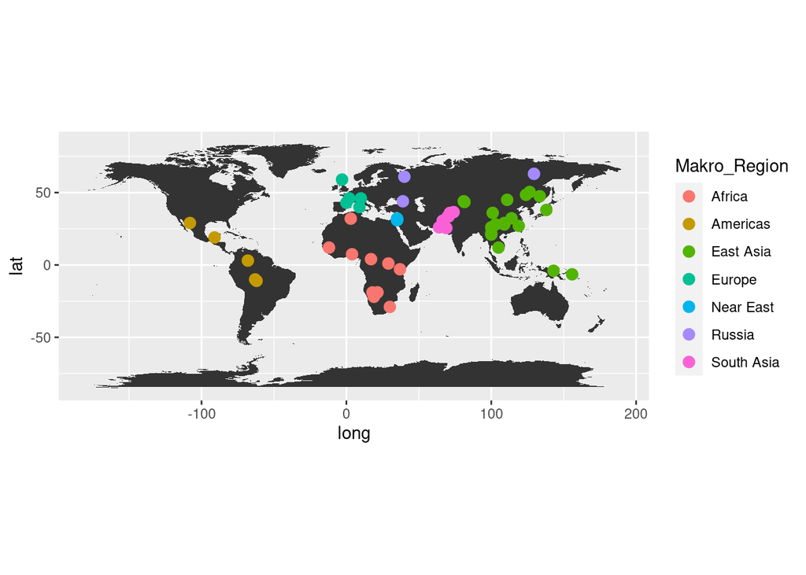

```r
world <- map_data("world")
ggplot() +
  geom_map(data = world, map = world, aes(long, lat, map_id = region)) +
  geom_point(data = context_info, aes(Longitude, Latitude, colour = Makro_Region), size = 3) +
  coord_fixed()
```

For each individual we extracted the same <50000 non-missing SNPs from the HumanOrigins SNP array ([Patterson 2012](https://doi.org/10.1534/genetics.112.145037)). They are available in a large `geno_matrix` text file, that can be loaded into R like this:

```r
geno_matrix <- scan("geno_matrix_one.txt", what = "character") %>%
  strsplit("") %>%
  do.call(rbind, .) %>%
  apply(., 2, as.numeric)
```

This large matrix contains more than 2 million entries and requires about 20MB of memory. Nevertheless we can still conveniently and interactively work with it in R. It features 54 rows, one for each individual, and one column for each of the 42482 SNPs. Each cell has either the value 0, 1 or 2 and – although this is technically discrete data – we’ll treat it as continuously scaled.

```r
str(geno_matrix)
```

```
##  num [1:54, 1:42482] 1 0 0 0 1 0 2 1 1 1 ...
```

### Running PCA

To explore this complex dataset we can run PCA on it, e.g. with `stats::prcomp()`:

```r
pca <- prcomp(geno_matrix)
```

Note how surprisingly fast the computation completes. The output object of this function is a complex beast, though.

```r
str(pca)
```

```
## List of 5
##  $ sdev    : num [1:54] 34 27.2 20.8 17.7 16.4 ...
##  $ rotation: num [1:42482, 1:54] -0.00443 -0.00177 -0.00168 -0.01119 0.00112 ...
##   ..- attr(*, "dimnames")=List of 2
##   .. ..$ : NULL
##   .. ..$ : chr [1:54] "PC1" "PC2" "PC3" "PC4" ...
##  $ center  : num [1:42482] 0.352 0.315 0.5 0.37 0.667 ...
##  $ scale   : logi FALSE
##  $ x       : num [1:54, 1:54] -3.74 -1.22 19.6 -2.21 0.69 ...
##   ..- attr(*, "dimnames")=List of 2
##   .. ..$ : NULL
##   .. ..$ : chr [1:54] "PC1" "PC2" "PC3" "PC4" ...
##  - attr(*, "class")= chr "prcomp"
```

Fortunately, most of the time we’re only interested in three fields for concrete applications:

- `$sdev`: standard deviations of the principal components
- `$rotation`: the matrix of variable loadings
- `$x`: the value of the rotated data (so: the coordinates of our input observations in PCA space)

From the standard deviations (`$sdev`) we can calculate the proportions of variance covered by the individual principal components:

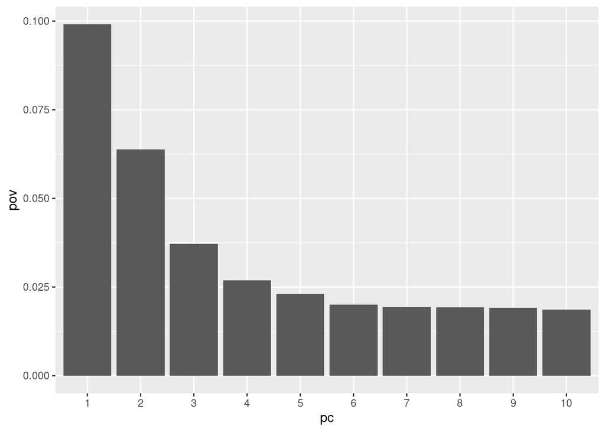

```r
pov <- pca$sdev^2/sum(pca$sdev^2)
pov_df <- tibble::tibble(pc = as.factor(1:10), pov = pov[1:10])
pov_df %>% ggplot() + geom_bar(aes(pc, pov), stat = "identity")
```

The variable loadings (`$rotation`) can be explored individually (though it’s a bit tedious for tens of thousands of SNPs) or used for projection (see lesson 2).

The output coordinates (`$x`) finally are most immediately useful to plot a “genetic map”.

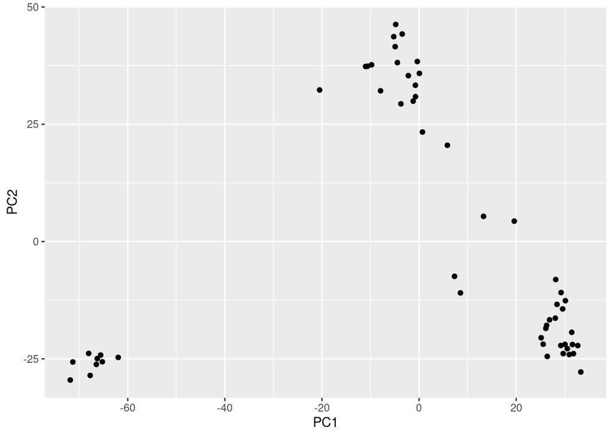

```r
pca$x %>%
  as.data.frame() %>%
  ggplot() +
  geom_point(aes(PC1, PC2))
```

This alone is of doubtful usefulness, as we can’t really interpret a random, unlabelled point cloud. We have to add meaningful context information. Fortunately we already have this available in the `context_info` object` and can combine the two.

```r
pca_tidy_obs <- pca$x %>%
  tibble::as_tibble() %>%
  dplyr::bind_cols(context_info)

pca_tidy_obs[c(1,2,(ncol(pca_tidy_obs)-5):ncol(pca_tidy_obs))]
```

```
## # A tibble: 54 × 8
##         PC1    PC2 Individual_ID Group_Name      Country      Longitude Latitude
##       <dbl>  <dbl> <chr>         <chr>           <chr>            <dbl>    <dbl>
##  1  -3.74    29.3  HGDP00001     Brahui          Pakistan          66.5     30.5
##  2  -1.22    29.9  HGDP00052     Balochi         Pakistan          66.5     30.5
##  3  19.6      4.34 HGDP00099     Hazara          Pakistan          70       33.5
##  4  -2.21    35.4  HGDP00131     Makrani         Pakistan          64       26
##  5   0.690   23.3  HGDP00167     Sindhi_Pakistan Pakistan          69       25.5
##  6  -0.741   30.9  HGDP00213     Pathan          Pakistan          70.5     33.5
##  7   0.0644  35.8  HGDP00277     Kalash          Pakistan          71.5     36.0
##  8   5.82    20.5  HGDP00336     Burusho         Pakistan          74       36.5
##  9 -71.3    -25.7  HGDP00449     Mbuti           Congo             29        1
## 10 -67.7    -28.5  HGDP00454     Biaka           Central Afr…      17        4
## # … with 44 more rows, and 1 more variable: Makro_Region <chr>
```

With this context data, the PCA plot can be rendered a lot more informative and useful.

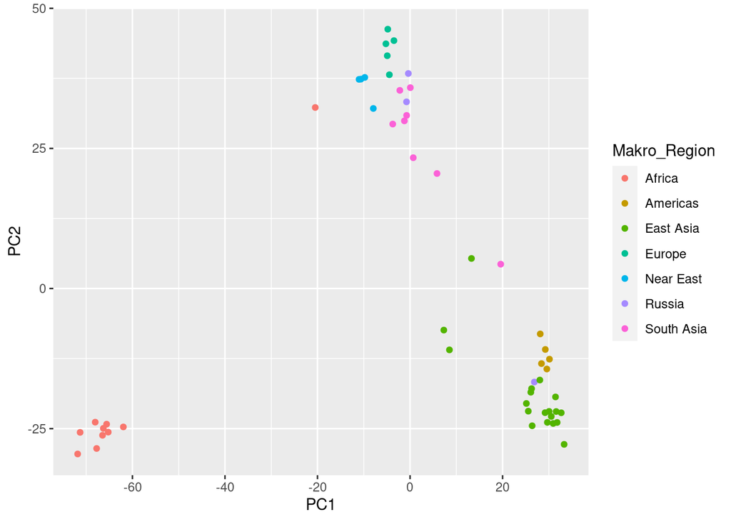

```r
pca_tidy_obs %>%
  ggplot() +
  geom_point(aes(PC1, PC2, color = Makro_Region))
```

We automated the described data preparation and plotting operations with a number of helper functions in a supplementary script file.

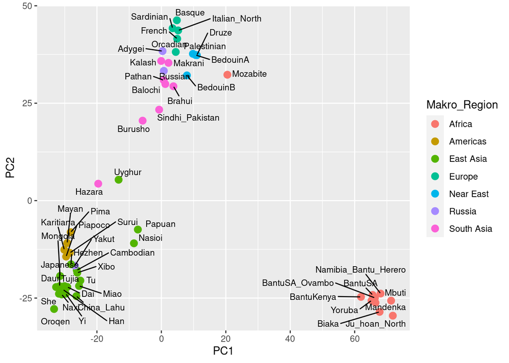

```r
source("helper_functions.R")

prcomp(geno_matrix) %>%
  tidy_pca_output() %>%
  plot_tidy_pca_simple(ggrepel::geom_text_repel, max.overlaps = Inf, use.labels = 'all')
```

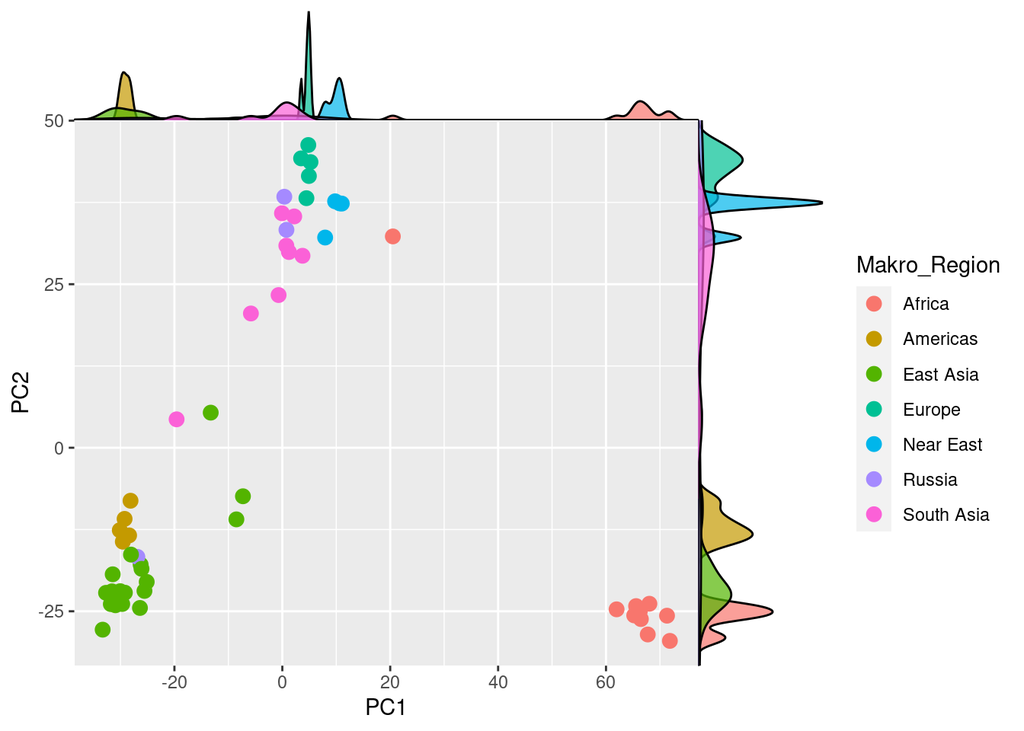

```r
prcomp(geno_matrix) %>%
  tidy_pca_output() %>%
  plot_tidy_pca_density()
```

Let’s discuss these plots!

### Creating missing data

To explore the effect of missing data on the PCA plot, we can artificially modify our currently complete dataset. Figuratively we can “shoot holes” into it. Here’s a simple matrix:

```r
x <- matrix(1:9, nrow = 3, ncol = 3, byrow = T)
x
```

```
##      [,1] [,2] [,3]
## [1,]    1    2    3
## [2,]    4    5    6
## [3,]    7    8    9
```

We can poke holes into it with a function like this:

```r
# shoot_holes()
destruction_level <- 0.3 # desired percentage of missingness
nr_holes <- round(destruction_level * prod(dim(x)))
holes <- sample(seq_along(x), size = nr_holes)
x_Emmentaler <- x
x_Emmentaler[holes] <- NA
x_Emmentaler
```

```
##      [,1] [,2] [,3]
## [1,]   NA    2    3
## [2,]   NA    5    6
## [3,]    7   NA    9
```

This implementation has one issue: it can accidentally wipe out entire columns. We want to avoid that for this experiment, so here’s an alternative implementation that removes the same proportion of values from each column.

```r
# shoot_holes_column_wise()
destruction_level <- 0.3 # desired percentage of missingness
nr_holes_per_column <- round((destruction_level * prod(dim(x)))/ncol(x))
x_Tilsit <- apply(x, 1, function(y) {
  holes <- sample(seq_along(y), size = nr_holes_per_column)
  y[holes] <- NA
  y
})
x_Tilsit
```

```
##      [,1] [,2] [,3]
## [1,]    1    4   NA
## [2,]    2    5    8
## [3,]   NA   NA    9
```

Equipped like this we can start to poke holes into our genotype data and run PCA on it.

```r
geno_perforated <- shoot_holes_column_wise(geno_matrix, 0.3)
prcomp(geno_perforated)
```

```
## Error in svd(x, nu = 0, nv = k): infinite or missing values in 'x'
```

This yields a nasty error message. `stats::prcomp()` can not run with perforated input data. So we’re forced to patch the holes.

### Filling missing data

#### Mean imputation

Mean imputation fills the missing values with the means of some observed values. We can write a column-wise mean imputation like this:

```r
patch_holes_mean <- function(x) {
  apply(x, 2, function(y) {
    y[is.na(y)] <- mean(y, na.rm = T)
    y
  })
}
```

… and then run it on our perforated dataset:

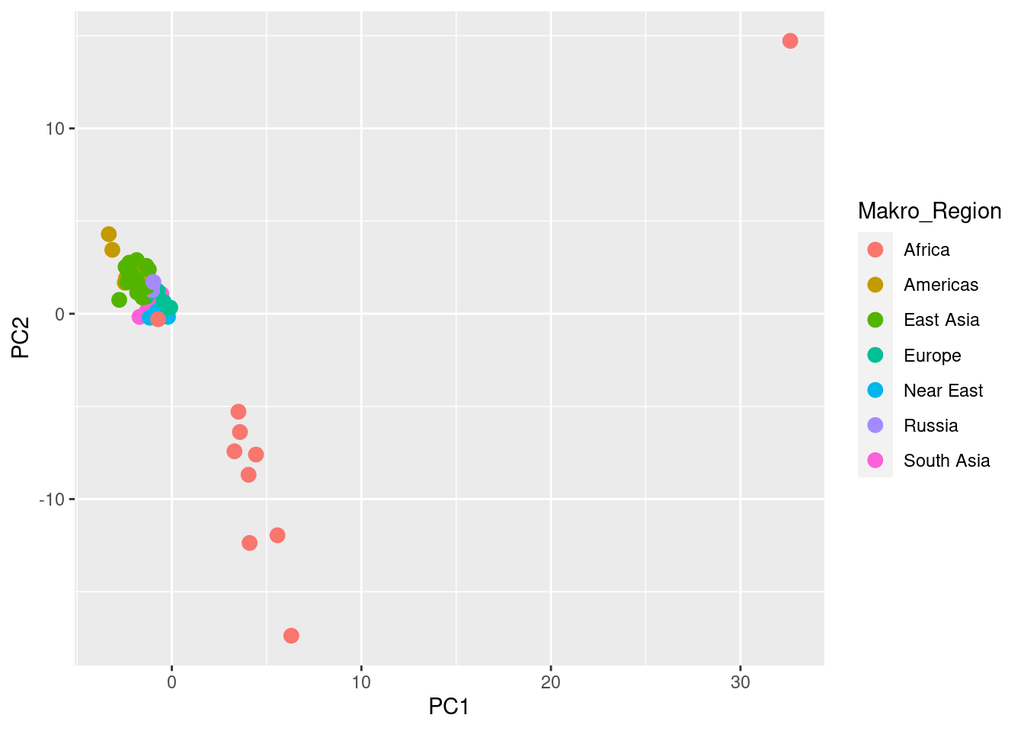

```r
geno_matrix %>%
  shoot_holes_column_wise(.9) %>%
  patch_holes_mean() %>%
  prcomp(geno_matrix) %>%
  tidy_pca_output() %>%
  plot_tidy_pca_simple()
```

The R package `missingMethods` provides a number of imputation algorithms, including the following three for mean imputation: `impute_mean()`, `impute_median()`, and `impute_mode`. The first one should behave identically to our own implementation `patch_holes_mean()`. We can compare their effects with the helper function `explore_filling_method()`, which wraps the whole pipeline from data, to imputation, to plot.

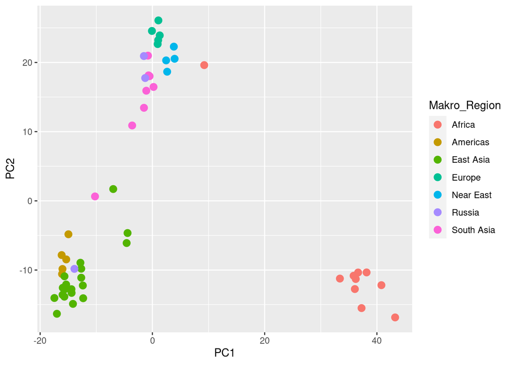

```r
geno_matrix %>% explore_filling_method(missMethods::impute_mean, destruction_level = 0.5)
```

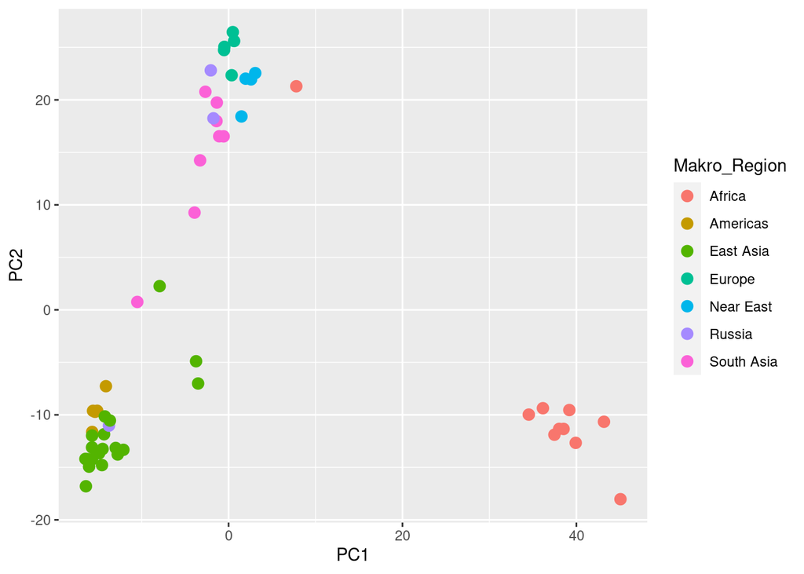

```r
geno_matrix %>% explore_filling_method(missMethods::impute_median, 0.5)
```

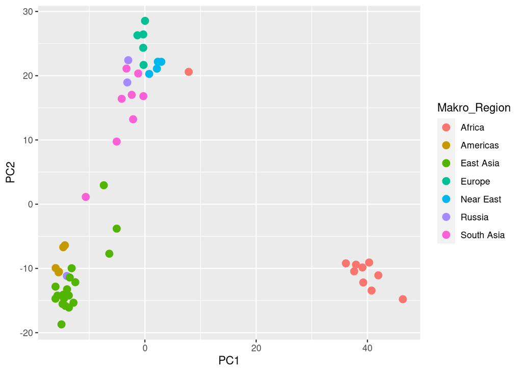

```r
geno_matrix %>% explore_filling_method(missMethods::impute_mode, 0.5)
```

Let’s play with these functions. Do they differ? Modify the `destruction_level` parameter! You can also do so with this tiny shiny app:

```r
shinyImpute()
```

### Variable levels of missingness

A short brief of non-uniform missigness. This will randomly add between 10 and 90% missingness to data:

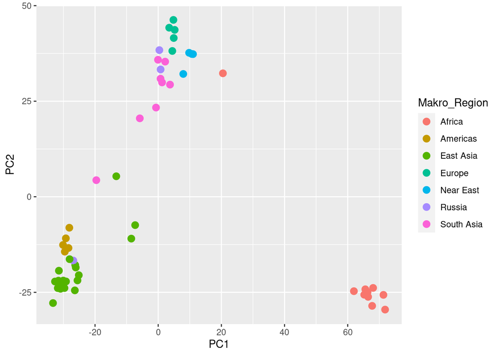

```r
p_basic = geno_matrix %>% prcomp %>% tidy_pca_output %>% plot_tidy_pca_simple
p_basic
```

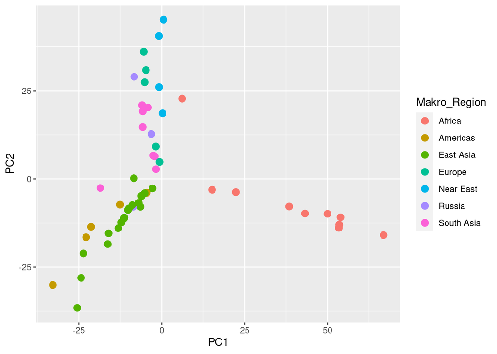

```r
Y = geno_matrix %>%
   shoot_holes_column_wise_nonunif(0.1, .9)

p_meanimpute = Y %>%
   patch_holes_mean %>%
   prcomp(geno_matrix) %>%
   tidy_pca_output() %>%
   plot_tidy_pca_simple()
p_meanimpute
```

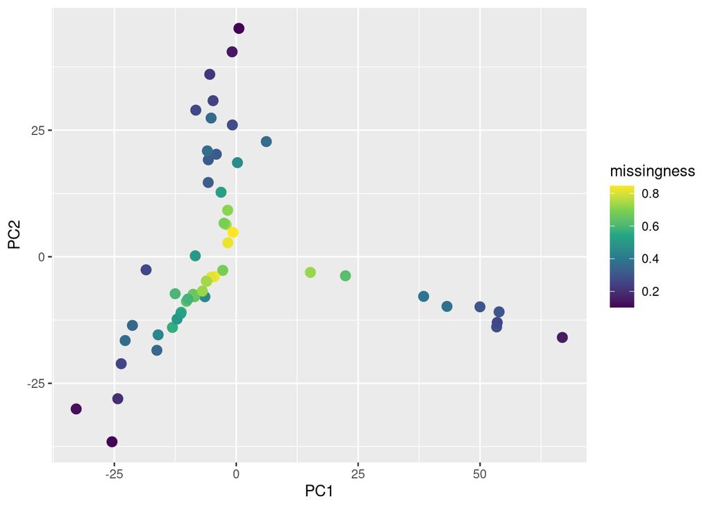

```r
# missingness plot
Y %>%
  patch_holes_mean %>%
  prcomp(geno_matrix) %>%
  tidy_pca_output() %>%
  dplyr::mutate(
    missingness = apply(Y, 1, function(x) { sum(is.na(x)) })/ncol(Y)
  ) %>%
  ggplot() +
  geom_point(
    aes(x = PC1, y = PC2, colour = missingness ),
    size = 3
  ) +
  scale_color_viridis_c()
```

```r
#compare to softimpute
require(softImpute)
```

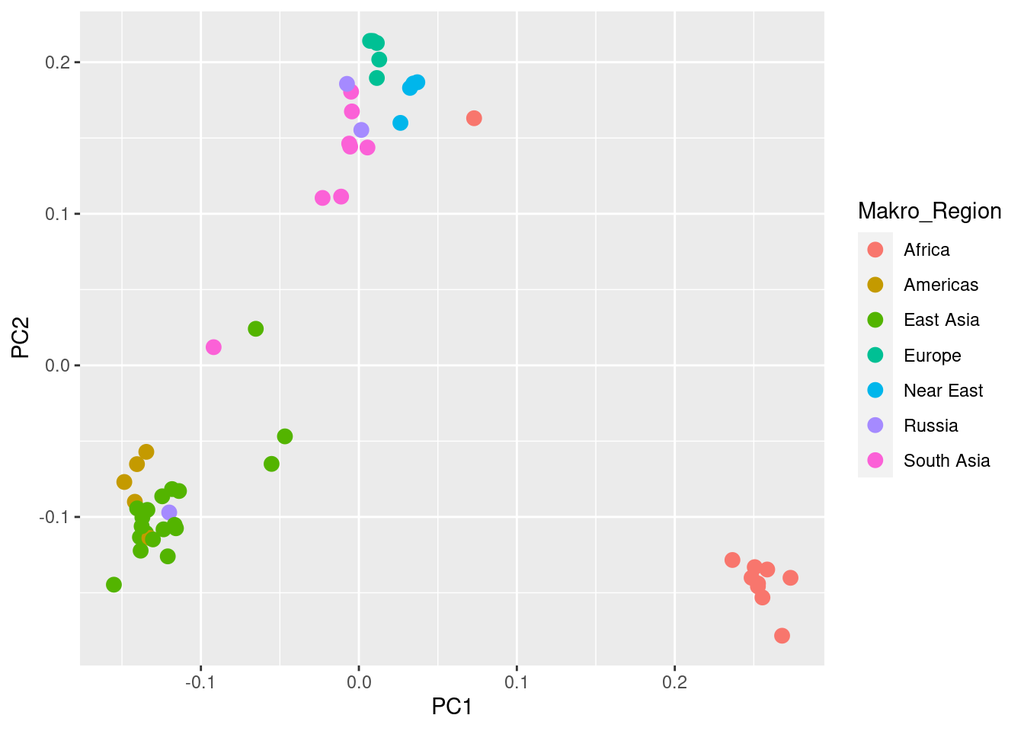

```r
y_softimpute = Y %>% scale(scale=F) %>% softImpute
y_softimpute$x = y_softimpute$u
colnames(y_softimpute$x) = sprintf("PC%d", 1:ncol(y_softimpute$x))
p_softimpute = y_softimpute %>% tidy_pca_output %>% plot_tidy_pca_simple()
p_softimpute
```

### Messy missingness

The setup here is that we want missingness to vary by macro-region

```r
library(dplyr)
df_missingness = context_info %>% select(Makro_Region) %>% distinct
df_missingness$missing = c(.2, .7, .3, .5, .2, .8, .6)
context_missing = context_info %>% left_join(df_missingness) %>% mutate(missing=runif(54,missing-.1, missing+.1))
head(context_missing)
```

```
## # A tibble: 6 × 7
##   Individual_ID Group_Name      Country  Longitude Latitude Makro_Region missing
##   <chr>         <chr>           <chr>        <dbl>    <dbl> <chr>          <dbl>
## 1 HGDP00001     Brahui          Pakistan      66.5     30.5 South Asia     0.159
## 2 HGDP00052     Balochi         Pakistan      66.5     30.5 South Asia     0.197
## 3 HGDP00099     Hazara          Pakistan      70       33.5 South Asia     0.133
## 4 HGDP00131     Makrani         Pakistan      64       26   South Asia     0.201
## 5 HGDP00167     Sindhi_Pakistan Pakistan      69       25.5 South Asia     0.278
## 6 HGDP00213     Pathan          Pakistan      70.5     33.5 South Asia     0.263
```

```r
shoot_holes_by_sample <- function(x, n_missing){
  n_samples = nrow(x)
  n_snps = ncol(x)
  n_missing = round(n_snps * n_missing)
  for(i in 1:n_samples){
    holes <- sample(seq(n_snps), size = n_missing[i])
    x[i, holes] <- NA
  }
  x
}
```

```r
Y = geno_matrix %>%
   shoot_holes_by_sample(context_missing$missing)

y_meanimpute = Y %>%
   patch_holes_mean %>%
   prcomp(geno_matrix) %>%
   tidy_pca_output(context_missing)
```

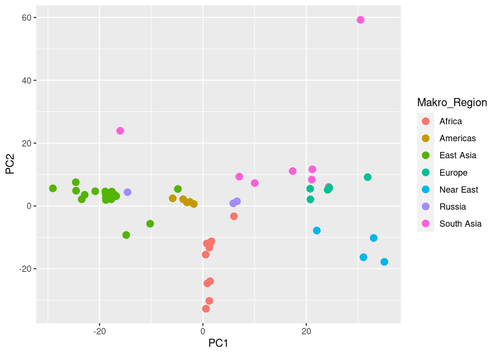

```r
p_meanimpute = y_meanimpute %>%
   plot_tidy_pca_simple()
p_meanimpute
```

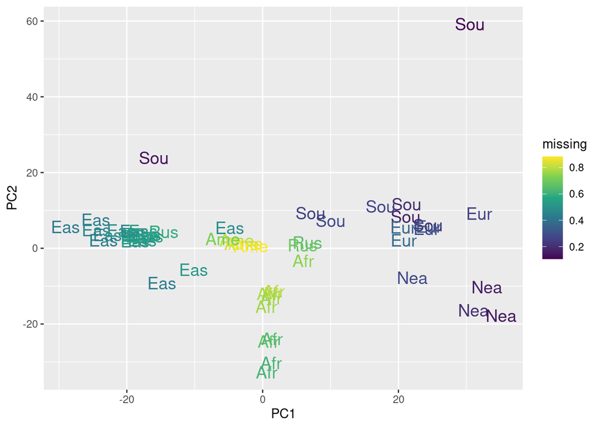

```r
p_meanimpute2 =   y_meanimpute %>%
  ggplot() +
  geom_text(
    aes(x = PC1, y = PC2, colour = missing, label=substr(Makro_Region, 1,3 )),
    size = 5
  ) +
  scale_color_viridis_c()
p_meanimpute2
```

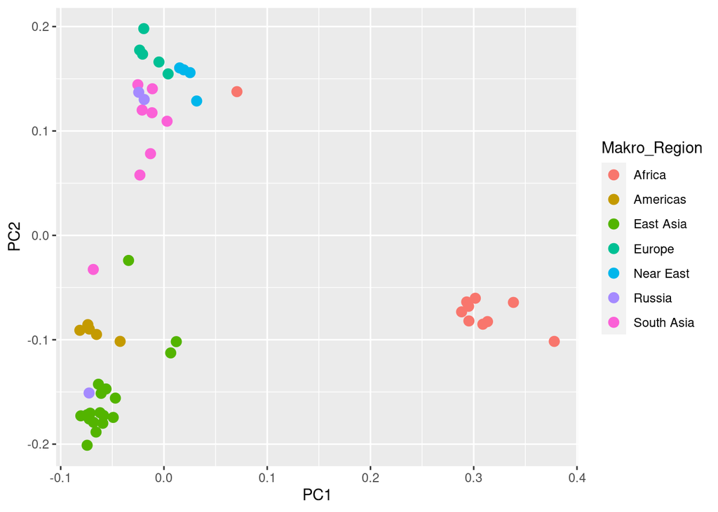

```r
#compare to softimpute
require(softImpute)
y_softimpute = Y %>% scale(scale=F) %>% softImpute
y_softimpute$x = y_softimpute$u
colnames(y_softimpute$x) = sprintf("PC%d", 1:ncol(y_softimpute$x))
p_softimpute = y_softimpute %>% tidy_pca_output %>% plot_tidy_pca_simple()
p_softimpute
```

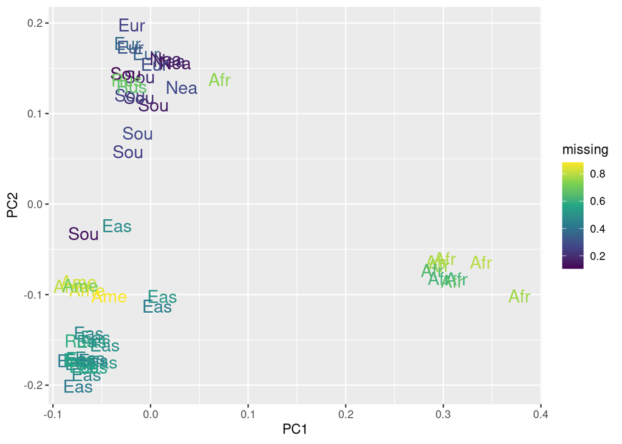

```r
p_softimpute2 =   y_softimpute %>% tidy_pca_output(context=context_missing)%>%
  ggplot() +
  geom_text(
    aes(x = PC1, y = PC2, colour = missing, label=substr(Makro_Region, 1,3 )),
    size = 5
  ) +
  scale_color_viridis_c()
p_softimpute2
```

### Other imputation algorithms

There are many different imputation algorithms. Here’s just a selection of them for imputation of numerical data that could be applied to genotype data (to my understanding). For large datasets some algorithms have exceedingly long runtimes and large memory requirements.

- `missMethods::impute_sRHD` (Simple random hot deck imputation)
- `missMethods::impute_EM` (an EM imputation algorithm)
- `softImpute::softImpute` (Imputation with nuclear-norm regularization)
- `mice::mice(method = 'pmm')` (Multivariate Imputation by Chained Equations: Predictive Mean Matching)
- `Amelia::amelia` (another EM multiple imputation algorithm)
- `missForest::missForest` (Nonparametric imputation using Random Forest)
- `Hmisc::aregImpute` (Imputation using additive regression, bootstrapping, and predictive mean matching)
- `mi::mi` (Imputation in an approximate Bayesian framework)

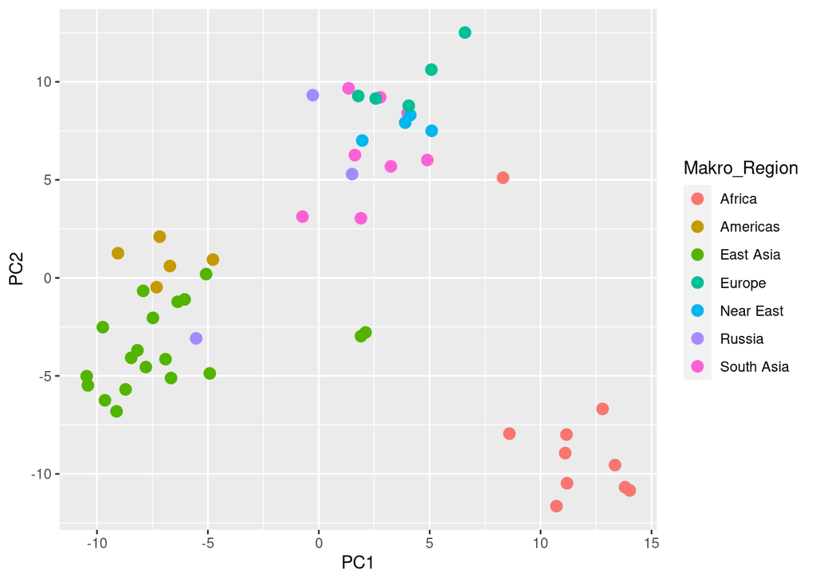

```r
geno_matrix_small <- geno_matrix[,1:2000] # reduced dataset for performance reasons

geno_matrix_small %>%
  prcomp(geno_matrix) %>%
  tidy_pca_output() %>%
  plot_tidy_pca_simple()
```

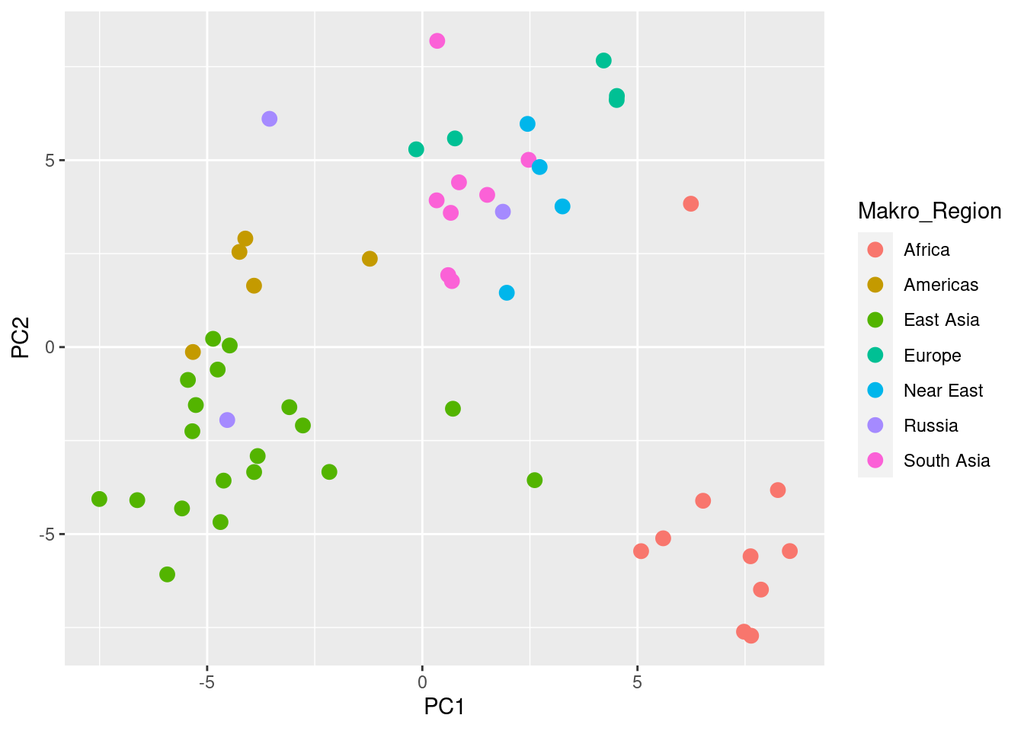

```r
geno_matrix_small %>% explore_filling_method(missMethods::impute_sRHD, destruction_level = 0.5)
```

```r
#geno_matrix_small %>% explore_filling_method(missMethods::impute_EM, destruction_level = 0.5)
# high runtime and memory requirements
#geno_matrix_small %>% explore_filling_method(softImpute::softImpute, destruction_level = 0.5)
# fails with Error in colMeans(x, na.rm = TRUE) : 'x' must be numeric
#geno_matrix_small %>% explore_filling_method(mice::mice, destruction_level = 0.5, method = 'pmm')
# long runtime
#geno_matrix_small %>% explore_filling_method(Amelia::amelia, destruction_level = 0.5)
# fails with Amelia Error Code:  43, You have a variable in your dataset that does not vary.  Please remove this variable.
#geno_matrix_small %>% explore_filling_method(missForest::missForest, destruction_level = 0.5)
# long runtime
```

That was sobering.

#### Imputation in classes

Probably most (?) of these algorithms can be applied to meaningful subsets of data to leverage known context information. The missMethods package provides a useful helper function `impute_in_classes` for that.

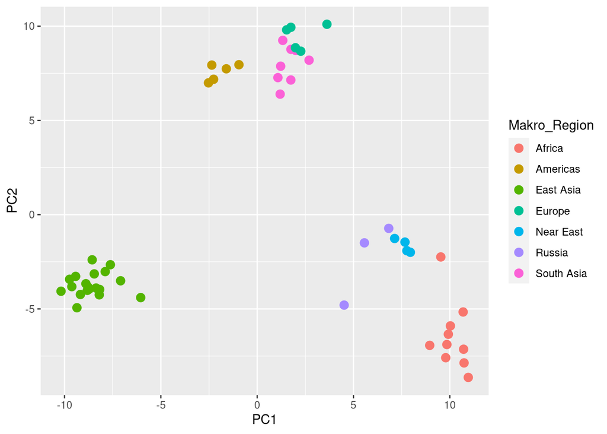

```r
geno_matrix_small %>%
  shoot_holes_column_wise(0.5) %>%
  as.data.frame() %>%
  dplyr::mutate(Makro_Region = context_info$Makro_Region) %>%
  missMethods::impute_in_classes(cols_class = "Makro_Region", missMethods::impute_mean) %>%
  dplyr::select(-Makro_Region) %>%
  as.matrix() %>%
  prcomp(geno_matrix) %>%
  tidy_pca_output() %>%
  plot_tidy_pca_simple()
```

Note the strong effect of group-wise imputation!